# Final Project: Disaster Tweet Classification

Data import, exploration, and cleaning. Because this data is part of an open kaggle competition, the test set has no target variables so we will make our own test set.

```r
raw_data <- read.csv("train.csv", na.strings = "")
raw_submission <- read.csv("test.csv", na.strings = "")

str(raw_data)
```

```
'data.frame':   7613 obs. of  5 variables:
 $ id      : int  1 4 5 6 7 8 10 13 14 15 ...
 $ keyword : chr  NA NA NA NA ...
 $ location: chr  NA NA NA NA ...
 $ text    : chr  "Our Deeds are the Reason of this #earthquake May ALLAH Forgive us all" "Forest fire near La Ronge Sask. Canada" "All residents asked to 'shelter in place' are being notified by officers. No other evacuation or shelter in pla"| __truncated__ "13,000 people receive #wildfires evacua…
 $ target  : int  1 1 1 1 1 1 1 1 1 1 ...
```

```r
summary(raw_data)
```

```
       id          keyword            location             text               target
 Min.   :    1   Length:7613        Length:7613        Length:7613        Min.   :0.0000
 1st Qu.: 2734   Class :character   Class :character   Class :character   1st Qu.:0.0000
 Median : 5408   Mode  :character   Mode  :character   Mode  :character   Median :0.0000
 Mean   : 5442                                                            Mean   :0.4297
 3rd Qu.: 8146                                                            3rd Qu.:1.0000
 Max.   :10873                                                            Max.   :1.0000
```

Check for missing variables. The variable keyword has 61 NA’s, while location has 2533.

```r
print("Number of missing values")
```

```
[1] "Number of missing values"
```

```r
colSums(is.na(raw_data))
```

```
      id  keyword location     text   target
       0       61     2533        0        0
```

```r
print("Percentage of missing values")
```

```
[1] "Percentage of missing values"
```

```r
round(colMeans(is.na(raw_data[ ,colSums(is.na(raw_data)) > 0])), 3) * 100
```

```
 keyword location
     0.8     33.3
```

Check if outcome variable target is balanced. The target variable is fairly balanced at around 43/57 split for true/false.

```r
sprintf("Number of 0's in target variable: %i", nrow(raw_data[raw_data$target == 0, ]))
```

```
[1] "Number of 0's in target variable: 4342"
```

```r
sprintf("Number of 1's in target variable: %i", nrow(raw_data[raw_data$target == 1, ]))
```

```
[1] "Number of 1's in target variable: 3271"
```

```r
sprintf("Percentage 0: %f", nrow(raw_data[raw_data$target == 0, ]) / nrow(raw_data) * 100)
```

```
[1] "Percentage 0: 57.034021"
```

```r
sprintf("Percentage 1: %f", nrow(raw_data[raw_data$target == 1, ]) / nrow(raw_data) * 100)
```

```
[1] "Percentage 1: 42.965979"
```

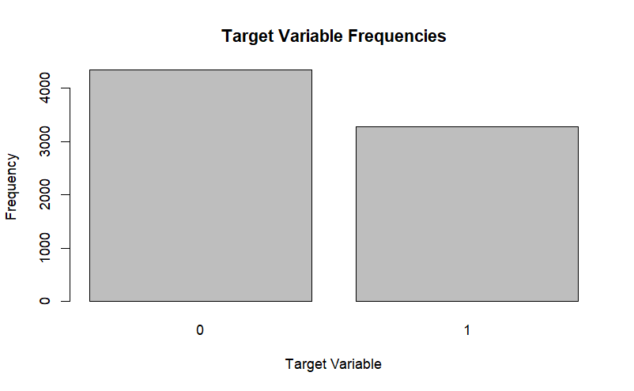

```r
barplot(table(raw_data$target), xlab = "Target Variable", ylab = "Frequency", main = "Target Variable Frequencies")
```

EXPLORE VARIABLE “keyword”

First, some rows in the keyword column have two keywords concatenated together separated by the characters “%20”. Examples include “airplane accident” and “body bag”. Since the separated words have a meaning that is different from either word on its own, we will replace these characters with a space.

```r
cleaned_data <- raw_data
cleaned_data$keyword  <- sapply(raw_data$keyword, function(x) {gsub("%20", " ", x)})
```

Lets look at a word cloud for keyword variable for false and true disasters. The two word clouds are a bit different, indicating different frequencies for true and false disaster tweets.

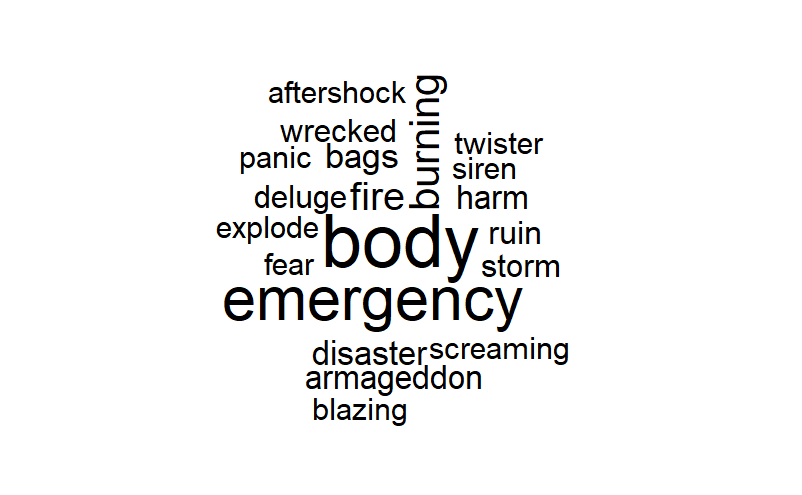

```r
library(wordcloud)
library(tm)

keywords <- Corpus(VectorSource(cleaned_data[cleaned_data$target == 0, ]$keyword))
wordcloud(keywords, max.words = 20, random.order = FALSE)
```

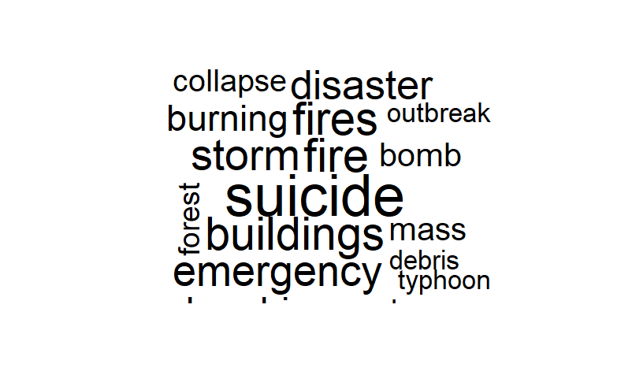

```r
keywords <- Corpus(VectorSource(cleaned_data[cleaned_data$target == 1, ]$keyword))
wordcloud(keywords, max.words = 20, random.order = FALSE)
```

Determine the number of unique words in the “keyword” variable. There are only 222 unique keyword values.

```r
sprintf("Number of unique keywords: %i", length(unique(cleaned_data$keyword)))
```

```
[1] "Number of unique keywords: 222"
```

Get the frequency plot of keyword. The keywords have a fairly uniform frequency.

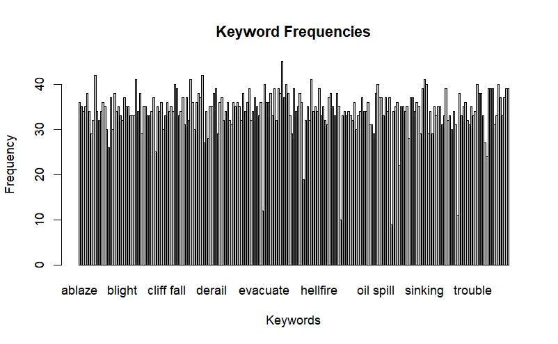

```r
barplot(table(cleaned_data$keyword), xlab = "Keywords", ylab = "Frequency", main = "Keyword Frequencies")
```

Examine distribution of target variable in keywords. The keywords are not evenly distributed between the ‘real disaster’ and ‘not real disaster’ categories. The keywords encode information about whether the tweet is about a real disaster or not so we will keep the variable “keyword”.

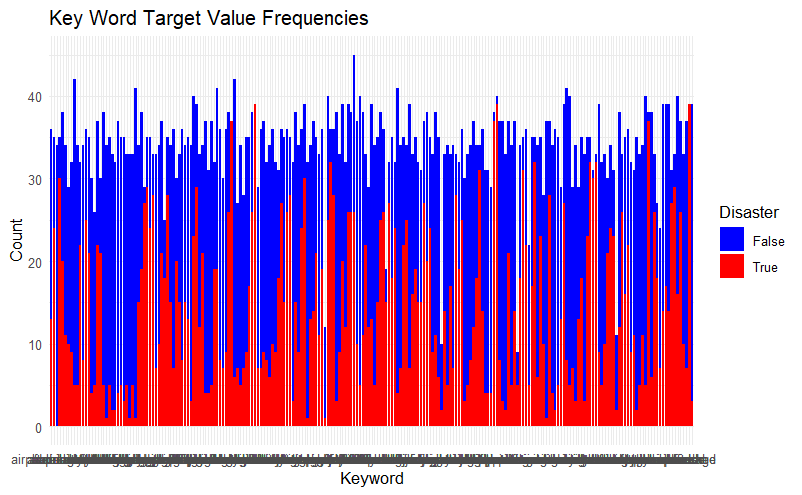

```r
library(ggplot2)

# Create a stacked bar plot
ggplot(as.data.frame(table(cleaned_data$keyword, raw_data$target)), aes(x = Var1, y = Freq, fill = Var2)) +
  geom_bar(stat = "identity") +
  labs(
    title = "Key Word Target Value Frequencies",
    x = "Keyword",
    y = "Count",
    fill = "Disaster"
  ) +
  scale_fill_manual(values = c("0" = "blue", "1" = "red"), labels = c("False", "True")) + theme_minimal()
```

Here is a frequency plot of the first 20 keywords and their target values.

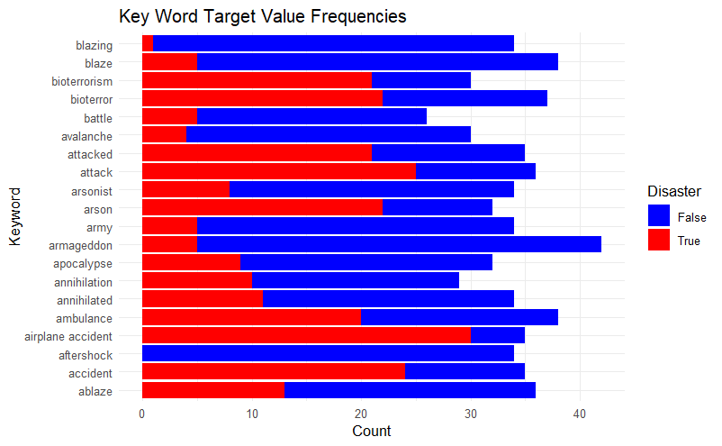

```r
# Create a stacked bar plot for the first 20 keywords
freq_plot <- ggplot(as.data.frame(table(cleaned_data$keyword, raw_data$target)[1:20, ]),
                    aes(x = Var1, y = Freq, fill = Var2)) +
  geom_bar(stat = "identity") +
  labs(
    title = "Key Word Target Value Frequencies",
    x = "Keyword",
    y = "Count",
    fill = "Disaster"
  ) +
  scale_fill_manual(values = c("0" = "blue", "1" = "red"), labels = c("False", "True")) + theme_minimal()
freq_plot + coord_flip()
```

Before we can impute the missing keywords, we need to check the distribution of the NA values on the target variable. Missing keywords are strongly associated with real disaster tweets, so we will keep them.

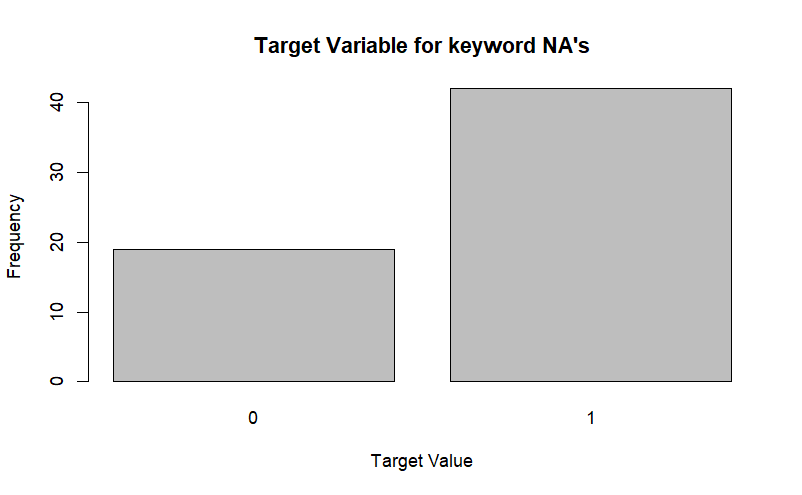

```r
barplot(table(raw_data[is.na(cleaned_data$keyword), ]$target),xlab = "Target Value",
        ylab = "Frequency", main = "Target Variable for keyword NA's")
```

EXPLORE VARIABLE “location”

Determine number of unique locations in the location variable. There are 3,342 unique values of location.

```r
sprintf("Number of unique locations: %i", length(unique(raw_data$location)))
```

```
[1] "Number of unique locations: 3342"
```

Get the frequency plot of “location”. The keywords are sparse.

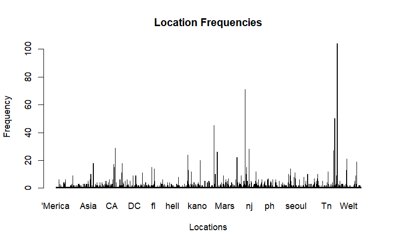

```r
barplot(table(raw_data$location), xlab = "Locations", ylab = "Frequency", main = "Location Frequencies")
```

Examine distribution of target variable in locations. The locations are not evenly distributed between the ‘real disaster’ and ‘not real disaster’ categories. While extremely sparse, a few location values seem to encode information about the target variable.

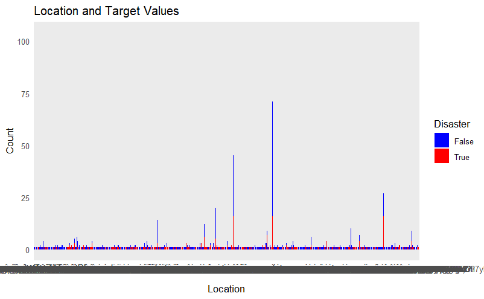

```r
library(ggplot2)

# Create a stacked bar plot
ggplot(as.data.frame(table(raw_data$location, raw_data$target)), aes(x = Var1, y = Freq, fill = Var2)) +
  geom_bar(stat = "identity") +
  labs(
    title = "Location and Target Values",
    x = "Location",
    y = "Count",
    fill = "Disaster"
  ) +
  scale_fill_manual(values = c("0" = "blue", "1" = "red"), labels = c("False", "True")) + theme_minimal()
```

Here is a frequency plot of the first 20 locations and their target values.

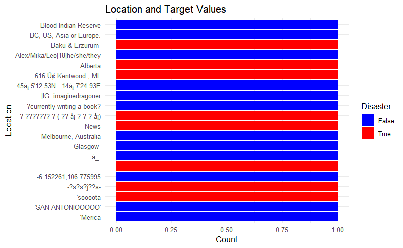

```r
# Create a stacked bar plot for the first 20 keywords
freq_plot <- ggplot(as.data.frame(table(raw_data$location, raw_data$target)[1:20, ]), aes(x = Var1, y = Freq, fill = Var2)) +
  geom_bar(stat = "identity") +
  labs(
    title = "Location and Target Values",
    x = "Location",
    y = "Count",
    fill = "Disaster"
  ) +
  scale_fill_manual(values = c("0" = "blue", "1" = "red"), labels = c("False", "True")) + theme_minimal()
freq_plot + coord_flip()
```

Before we can impute the missing locations, we need to check the distribution of the NA values on the target variable. It seems false disaster tweets are more likely to lack a location.

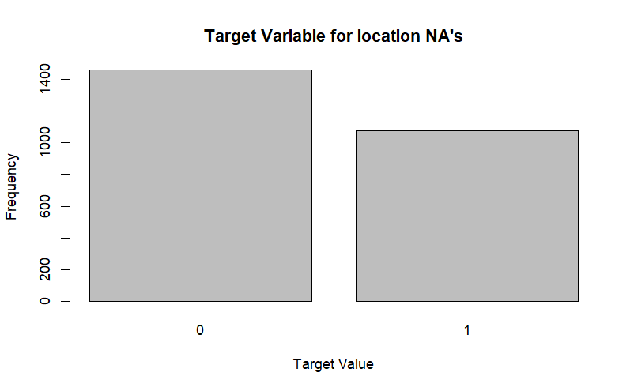

```r
barplot(table(raw_data[is.na(raw_data$location), ]$target), xlab = "Target Value",
        ylab = "Frequency", main = "Target Variable for location NA's")
```

EXPLORE VARIABLE “text”

Before proceeding me must clean the raw tweets.

```r
library(tm)
tweet_corpus <- VCorpus(VectorSource(raw_data$text))
tweet_corpus <- tm_map(tweet_corpus, content_transformer(tolower))
tweet_corpus <- tm_map(tweet_corpus, removeWords, stopwords("english"))

toSpace <- content_transformer(function(x, pattern) gsub(pattern, " ", x))

tweet_corpus <- tm_map(tweet_corpus, toSpace, "(s?)(f|ht)tp(s?)://\\S+\\b")
tweet_corpus <- tm_map(tweet_corpus, toSpace, "#[[:alnum:]_]+")
tweet_corpus <- tm_map(tweet_corpus, toSpace, "/")
tweet_corpus <- tm_map(tweet_corpus, toSpace, "@")
tweet_corpus <- tm_map(tweet_corpus, toSpace, "\\|")
tweet_corpus <- tm_map(tweet_corpus, removeNumbers)
library(SnowballC)
tweet_corpus <- tm_map(tweet_corpus, stemDocument)
tweet_corpus <- tm_map(tweet_corpus, removePunctuation)
tweet_corpus <- tm_map(tweet_corpus, stripWhitespace)

text <- data.frame(text=unlist(sapply(tweet_corpus, `[`, "content")), stringsAsFactors=F)
cleaned_data$text <- text$text
```

```r
sprintf("Number of unique words: %i", length(unique(cleaned_data$text)))
```

```
[1] "Number of unique words: 6827"
```

Below is a word cloud for the text variable for true and false disasters.

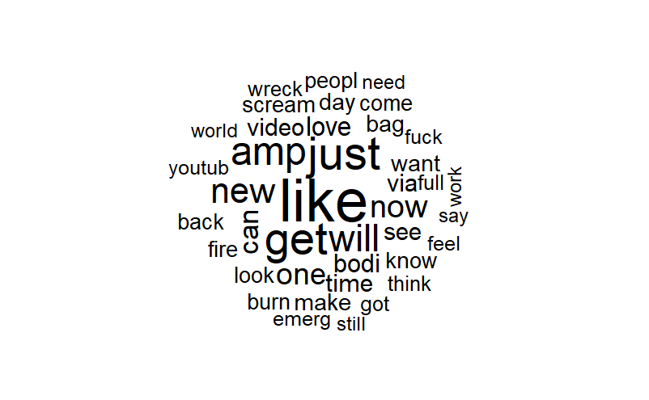

```r
text <- Corpus(VectorSource(cleaned_data[cleaned_data$target == 0, ]$text))
wordcloud(text, max.words = 40, random.order = FALSE)
```

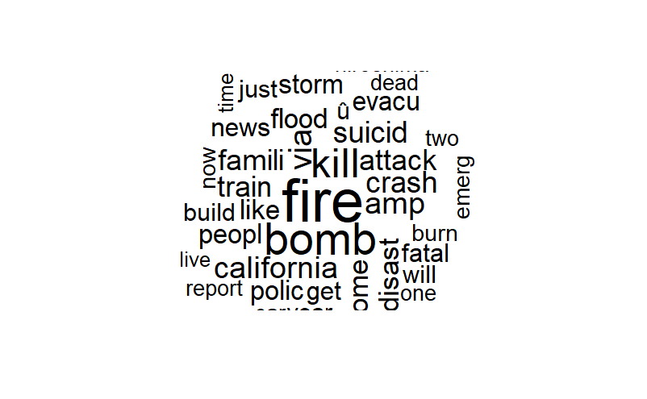

```r
text <- Corpus(VectorSource(cleaned_data[cleaned_data$target == 1, ]$text))
wordcloud(text, max.words = 40, random.order = FALSE)
```

Find the average word count for both values of the target variable. Tweets about real disasters have more words on average.

```r
f <- sapply(cleaned_data[cleaned_data$target == 0, ]$text, function(x) {lengths(strsplit(x, " "))})
sprintf("Average number of words in false disaster tweets: %f", mean(f))
```

```
[1] "Average number of words in false disaster tweets: 8.469830"
```

```r
t <- sapply(cleaned_data[cleaned_data$target == 1, ]$text, function(x) {lengths(strsplit(x, " "))})
sprintf("Average number of words in true disaster tweets: %f", mean(t))
```

```
[1] "Average number of words in true disaster tweets: 9.200856"
```

Now lets look at the distribution of word counts for true and false disaster tweets. The distributions are different.

```r
blue <- rgb(0, 0, 1, alpha=0.5)
red <- rgb(1, 0, 0, alpha=0.5)
barplot(table(f), col = blue, main="Word Counts for Tweets", xlab = "Word Count", ylab = "Frequency")
barplot(table(t), col = red, xaxt='n', add = TRUE)
```

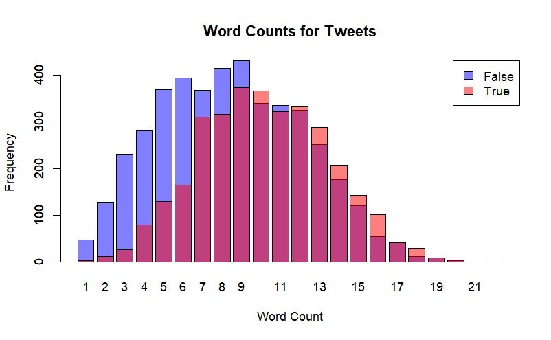

```r
legend("topright", legend = c("False", "True"), fill = c(blue, red))
```

```r
barplot(table(round(f, 0.5)), col = blue, main="Average Word Lengths for Tweets",
        xlab = "Character Count Per Word", ylab = "Frequency")
barplot(table(round(t, 0.5)), col = red, xaxt='n', add = TRUE)
```

[figure not shown]

```r
legend("topright", legend = c("False", "True"), fill = c(blue, red))
```

DATA IMPUTATION

First lets graph the missing data.

```
 Variables sorted by number of missings:
```

| Variable | Count |
| --- | --- |
| location | 0.33272035 |
| keyword | 0.00801261 |
| id | 0.00000000 |
| text | 0.00000000 |
| target | 0.00000000 |

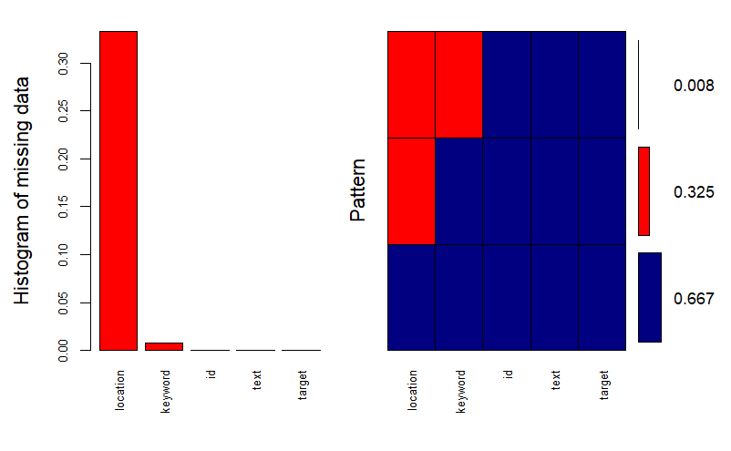

```r
library(VIM)
aggr_plot <- aggr(cleaned_data, col=c('navyblue','red'), numbers=TRUE, sortVars=TRUE, labels=names(cleaned_data), cex.axis=.7, gap=3, ylab=c("Histogram of missing data","Pattern"))
```

With no good method to impute these sparse string values in a data set with only 3 predictors, we will use the string “unknown” and “none” for imputation.

```r
cleaned_data[is.na(cleaned_data$location), ]$location <- 'unknown'
cleaned_data[is.na(cleaned_data$keyword), ]$keyword <- 'none'
```

Remove the id variable and split the cleaned data into training and test.

```r
set.seed(1)
library(caret, quietly = TRUE)

cleaned_data <- subset(cleaned_data, select = -id)
cleaned_data$target <- factor(cleaned_data$target)

inTrain <- createDataPartition(cleaned_data$keyword, p=0.9, list=FALSE)
train <- cleaned_data[inTrain, ]
test <- cleaned_data[-inTrain, ]
```

FEATURE ENCODING

We will use feature hashing to handle the sparsity of the keyword variable.

```r
set.seed(1)

library(textrecipes)

recipe <- recipe(~keyword, data = train) %>% step_dummy_hash(keyword, num_terms = 25)
object <- recipe %>% prep()
train$keyword <- data.frame(bake(object, new_data = train))
test$keyword <- data.frame(bake(object, new_data = test))
```

We’ll also use feature hashing for the location variable.

```r
set.seed(1)

recipe = recipe(~location, data = train) %>% step_dummy_hash(location, num_terms = 5)
object= recipe %>% prep()
train$location = data.frame(bake(object, new_data = train))
test$location = data.frame(bake(object, new_data = test))
```

For the text variable we will use tf-idf encoding for the and z scale normalization.

```r
library(keras)
set.seed(1)

text_vectorizer <- layer_text_vectorization(output_mode="tf_idf", max_tokens = 500)
text_vectorizer %>% adapt(train$text)

train_tfidf <- as.matrix(text_vectorizer(train$text))
test_tfidf <- as.matrix(text_vectorizer(test$text))

train_tfidf <- scale(train_tfidf)
col_means_train <- attr(train_tfidf, "scaled:center")
col_stddevs_train <- attr(train_tfidf, "scaled:scale")
test_tfidf <- scale(test_tfidf, center = col_means_train, scale = col_stddevs_train)

train_tfidf <- as.data.frame(cbind(train_tfidf, as.matrix(subset(train, select = -text))))
test_tfidf <- as.data.frame(cbind(test_tfidf, as.matrix(subset(test, select = -c(text, target)))))

train_tfidf <- train_tfidf %>% mutate_if(is.character, as.numeric)
test_tfidf <- test_tfidf %>% mutate_if(is.character, as.numeric)
```

Function to create a cross table and print statistics.

```r
c_table <- function(predictions) {

  t <- table(test_labels, predictions)
  print(t)

  error <- (t[1,1] + t[2,2]) / nrow(test)
  print(sprintf("Accuracy: %f", error))

  precision <- t[2,2] / (t[2,2] + t[1,2])
  print(sprintf("Precision: %f", precision))

  recall <- t[2,2] / (t[2,2] + t[2,1])
  print(sprintf("Recall: %f", recall))

  f1_score <- (2 * precision * recall) / (precision + recall)
  print(sprintf("F1: %f", f1_score))
}

test_labels <- test$target
```

TRAINING AND TESTING MODELS

KNN model with with 10-fold cross validation.

```r
set.seed(1)
library(pROC)
library(ISLR)

knn_model <- train(factor(target) ~ .,
                data = train_tfidf,
                method = "knn",
                trControl = trainControl(method = "cv", number = 10))

knn_model
```

```
k-Nearest Neighbors

6957 samples
 530 predictor
   2 classes: '0', '1'

No pre-processing
Resampling: Cross-Validated (10 fold)
Summary of sample sizes: 6262, 6262, 6262, 6260, 6261, 6261, ...
Resampling results across tuning parameters:

  k  Accuracy   Kappa
  5  0.7175415  0.4056242
  7  0.7237294  0.4150216
  9  0.7188446  0.4017567

Accuracy was used to select the optimal model using the largest value.
The final value used for the model was k = 7.
```

```r
knn_predictions <- predict(knn_model, test_tfidf)
c_table(knn_predictions)
```

```
           predictions
test_labels   0   1
          0 339  39
          1 128 150
[1] "Accuracy: 0.745427"
[1] "Precision: 0.793651"
[1] "Recall: 0.539568"
[1] "F1: 0.642398"
```

```r
auc(test_labels, as.numeric(knn_predictions))
```

```
Area under the curve: 0.7182
```

Naive Bays Model with 10 fold cross validation.

```r
library(e1071)

naive_bayes_model <- train(factor(target) ~ .,
                           data = train_tfidf,
                           method = "naive_bayes",
                           trControl = trainControl(method = "cv", number = 10))


naive_bayes_model
```

```
Naive Bayes

6957 samples
 530 predictor
   2 classes: '0', '1'

No pre-processing
Resampling: Cross-Validated (10 fold)
Summary of sample sizes: 6261, 6262, 6261, 6260, 6261, 6261, ...
Resampling results across tuning parameters:

  usekernel  Accuracy   Kappa
  FALSE      0.7267532  0.4162182
   TRUE      0.5697859  0.0000000

Tuning parameter 'laplace' was held constant at a value of 0
Tuning parameter 'adjust' was held constant at a value of 1
Accuracy was used to select the optimal model using the largest value.
The final values used for the model were laplace = 0, usekernel = FALSE and adjust = 1.
```

```r
naive_bayes_predictions <- predict(naive_bayes_model, test_tfidf)
c_table(naive_bayes_predictions)
```

```
           predictions
test_labels   0   1
          0 334  44
          1 141 137
[1] "Accuracy: 0.717988"
[1] "Precision: 0.756906"
[1] "Recall: 0.492806"
[1] "F1: 0.596950"
```

```r
auc(test_labels, as.numeric(naive_bayes_predictions))
```

```
Area under the curve: 0.6882
```

Elastic Net Regression Model with 10-fold cross validation.

```r
set.seed(1)

elastic_model <- train(factor(target) ~ .,
                      data = train_tfidf,
                      method = "glmnet",
                      family = "binomial",
                      verbose = FALSE,
                      trControl = trainControl(method = "cv", number = 10))

elastic_model
```

```
glmnet

6957 samples
 530 predictor
   2 classes: '0', '1'

No pre-processing
Resampling: Cross-Validated (10 fold)
Summary of sample sizes: 6262, 6262, 6262, 6260, 6261, 6261, ...
Resampling results across tuning parameters:

  alpha  lambda        Accuracy   Kappa
  0.10   0.0001323339  0.7677115  0.5183376
  0.10   0.0013233389  0.7691487  0.5210864
  0.10   0.0132333889  0.7750430  0.5306436
  0.55   0.0001323339  0.7677117  0.5183401
  0.55   0.0013233389  0.7713035  0.5245834
  0.55   0.0132333889  0.7659843  0.5063626
  1.00   0.0001323339  0.7679995  0.5188546
  1.00   0.0013233389  0.7715931  0.5243263
  1.00   0.0132333889  0.7529060  0.4732931

Accuracy was used to select the optimal model using the largest value.
The final values used for the model were alpha = 0.1 and lambda = 0.01323339.
```

```r
suppressWarnings(elastic_predictions <- predict(elastic_model, test_tfidf))
c_table(elastic_predictions)
```

```
           predictions
test_labels   0   1
          0 327  51
          1  91 187
[1] "Accuracy: 0.783537"
[1] "Precision: 0.785714"
[1] "Recall: 0.672662"
[1] "F1: 0.724806"
```

```r
auc(test_labels, as.numeric(elastic_predictions))
```

```
Area under the curve: 0.7689
```

Random Forest Model with 10-fold cross validation.

```r
set.seed(1)

r_forest_model <- train(factor(target) ~ .,
                        data = train_tfidf,
                        method = "rf",
                        importance = TRUE,
                        verbose = FALSE,
                        trControl = trainControl(method = "cv", number = 10))


varImp(r_forest_model)
```

```
rf variable importance

  only 20 most important variables shown (out of 530)
```

|  | Importance |
| --- | --- |
| V15 | 100.00000 |
| V44 | 95.95642 |
| V30 | 91.42512 |
| V129 | 91.28689 |
| V3 | 85.18497 |
| V45 | 84.18832 |
| V50 | 81.88989 |
| V98 | 77.23702 |
| V421 | 76.18168 |
| V242 | 75.20355 |

[output cut: 10 more lines]

```r
r_forest_model
```

```
Random Forest

6957 samples
 530 predictor
   2 classes: '0', '1'

No pre-processing
Resampling: Cross-Validated (10 fold)
Summary of sample sizes: 6262, 6262, 6262, 6260, 6261, 6261, ...
Resampling results across tuning parameters:

  mtry  Accuracy   Kappa
    2   0.7083441  0.3560352
   32   0.7782054  0.5413178
  530   0.7553564  0.4970363

Accuracy was used to select the optimal model using the largest value.
The final value used for the model was mtry = 32.
```

```r
random_forest_predictions <- predict(r_forest_model, test_tfidf)
c_table(random_forest_predictions)
```

```
           predictions
test_labels   0   1
          0 323  55
          1  69 209
[1] "Accuracy: 0.810976"
[1] "Precision: 0.791667"
[1] "Recall: 0.751799"
[1] "F1: 0.771218"
```

```r
auc(test_labels, as.numeric(random_forest_predictions))
```

```
Area under the curve: 0.8031
```

Gradient Boosted Machine with 10-fold cross validation and hyper parameter tuning.

```r
set.seed(1)
library(gbm)
gbm_model <- train(factor(target) ~ .,
                    data = train_tfidf,
                    method = "gbm",
                    verbose = FALSE,
                    trControl = trainControl(method = "cv", number = 10))

gbm_model
```

```
Stochastic Gradient Boosting

6957 samples
 530 predictor
   2 classes: '0', '1'

No pre-processing
Resampling: Cross-Validated (10 fold)
Summary of sample sizes: 6262, 6262, 6262, 6260, 6261, 6261, ...
Resampling results across tuning parameters:

  interaction.depth  n.trees  Accuracy   Kappa
  1                   50      0.6571716  0.2358913
  1                  100      0.6859207  0.3083815
  1                  150      0.7059028  0.3593217
  2                   50      0.6830492  0.3017835
  2                  100      0.7202706  0.3947107
  2                  150      0.7385297  0.4399057
  3                   50      0.7053281  0.3583007
  3                  100      0.7340738  0.4295269
  3                  150      0.7521914  0.4740167

Tuning parameter 'shrinkage' was held constant at a value of 0.1
Tuning parameter 'n.minobsinnode' was held constant at a value of 10
Accuracy was used to select the optimal model using the largest value.
The final values used for the model were n.trees = 150, interaction.depth = 3, shrinkage = 0.1 and n.minobsinnode = 10.
```

```r
gbm_predictions <- predict(gbm_model, test_tfidf)
c_table(gbm_predictions)
```

```
           predictions
test_labels   0   1
          0 349  29
          1 120 158
[1] "Accuracy: 0.772866"
[1] "Precision: 0.844920"
[1] "Recall: 0.568345"
[1] "F1: 0.679570"
```

```r
auc(test_labels, as.numeric(gbm_predictions))
```

```
Area under the curve: 0.7458
```

Support Vector Machine with 10 fold cross validation

```r
set.seed(1)
library(gbm)

svm_model <- train(factor(target) ~ .,
                    data = train_tfidf,
                    method = "svmLinear",
                    verbose = FALSE,
                    trControl = trainControl(method = "cv", number = 10))

svm_model
```

```
Support Vector Machines with Linear Kernel

6957 samples
 530 predictor
   2 classes: '0', '1'

No pre-processing
Resampling: Cross-Validated (10 fold)
Summary of sample sizes: 6262, 6262, 6262, 6260, 6261, 6261, ...
Resampling results:

  Accuracy  Kappa
  0.771167  0.5234279

Tuning parameter 'C' was held constant at a value of 1
```

```r
svm_predictions <- predict(svm_model, test_tfidf)
c_table(svm_predictions)
```

```
           predictions
test_labels   0   1
          0 326  52
          1  88 190
[1] "Accuracy: 0.786585"
[1] "Precision: 0.785124"
[1] "Recall: 0.683453"
[1] "F1: 0.730769"
```

```r
auc(test_labels, as.numeric(svm_predictions))
```

```
Area under the curve: 0.7729
```

Feed Forward Neural Network Model

First we need to create a validation set.

```r
set.seed(1)

nn_inTrain <- createDataPartition(train_tfidf$target, p=0.9, list=FALSE)
train_tfidf <- train_tfidf[nn_inTrain, ]
val_tfidf <- train_tfidf[-nn_inTrain, ]
```

Use tfruns to train different hyper parameter combinations.

```r
library(keras)
set.seed(1)

library(tfruns)
runs <- tuning_run("flags.R",
                    flags = list(
                     nodes1 = c(32, 64),
                     nodes2 = c(32, 64),
                     nodes3 = c(16, 32),
                     dropout = c(0.1, 0.3),
                     learning_rate = c(0.01, 0.001),
                     batch_size = c(64, 128),
                     activation1 = c("relu", "sigmoid"),
                     activation2 = c("relu", "sigmoid"),
                     activation3 = c("relu", "sigmoid")
                   ),
                   sample = 0.015)
```

```
512 total combinations of flags
(sampled to 8 combinations)

Training run 1/8 (flags = list(32, 32, 16, 0.3, 0.001, 128, "sigmoid", "sigmoid", "sigmoid"))
Using run directory runs/2024-05-06T19-08-22Z
```

[output not shown]

```
WARNING:tensorflow:Callback method `on_train_batch_end` is slow compared to the batch time (batch time: 0.0020s vs `on_train_batch_end` time: 0.0042s). Check your callbacks.

Run completed: runs/2024-05-06T19-08-22Z

Training run 2/8 (flags = list(64, 64, 16, 0.1, 0.01, 64, "sigmoid", "relu", "sigmoid"))
Using run directory runs/2024-05-06T19-09-06Z
```

[output not shown]

```
WARNING:tensorflow:Callback method `on_train_batch_end` is slow compared to the batch time (batch time: 0.0014s vs `on_train_batch_end` time: 0.0037s). Check your callbacks.

Run completed: runs/2024-05-06T19-09-06Z

Training run 3/8 (flags = list(32, 64, 32, 0.1, 0.01, 128, "relu", "sigmoid", "relu"))
Using run directory runs/2024-05-06T19-09-29Z
```

[output not shown]

```
WARNING:tensorflow:Callback method `on_train_batch_end` is slow compared to the batch time (batch time: 0.0021s vs `on_train_batch_end` time: 0.0033s). Check your callbacks.

Run completed: runs/2024-05-06T19-09-29Z

Training run 4/8 (flags = list(32, 32, 16, 0.1, 0.01, 64, "relu", "sigmoid", "relu"))
Using run directory runs/2024-05-06T19-09-41Z
```

[output not shown]

```
WARNING:tensorflow:Callback method `on_train_batch_end` is slow compared to the batch time (batch time: 0.0020s vs `on_train_batch_end` time: 0.0021s). Check your callbacks.

Run completed: runs/2024-05-06T19-09-41Z

Training run 5/8 (flags = list(64, 32, 16, 0.1, 0.01, 128, "relu", "sigmoid", "sigmoid"))
Using run directory runs/2024-05-06T19-10-01Z
```

[output not shown]

```
WARNING:tensorflow:Callback method `on_train_batch_end` is slow compared to the batch time (batch time: 0.0020s vs `on_train_batch_end` time: 0.0033s). Check your callbacks.

Run completed: runs/2024-05-06T19-10-01Z

Training run 6/8 (flags = list(32, 64, 32, 0.1, 0.001, 64, "sigmoid", "sigmoid", "sigmoid"))
Using run directory runs/2024-05-06T19-10-14Z
```

[output not shown]

```
Run completed: runs/2024-05-06T19-10-14Z

Training run 7/8 (flags = list(32, 64, 16, 0.3, 0.01, 128, "relu", "relu", "sigmoid"))
Using run directory runs/2024-05-06T19-11-02Z
```

[output not shown]

```
WARNING:tensorflow:Callback method `on_train_batch_end` is slow compared to the batch time (batch time: 0.0017s vs `on_train_batch_end` time: 0.0053s). Check your callbacks.

Run completed: runs/2024-05-06T19-11-02Z

Training run 8/8 (flags = list(64, 32, 32, 0.3, 0.01, 64, "relu", "relu", "sigmoid"))
Using run directory runs/2024-05-06T19-11-13Z
```

[output not shown]

```
WARNING:tensorflow:Callback method `on_train_batch_end` is slow compared to the batch time (batch time: 0.0016s vs `on_train_batch_end` time: 0.0037s). Check your callbacks.

Run completed: runs/2024-05-06T19-11-13Z
```

Find the best run.

```r
runs = runs[order(runs$metric_val_loss), ]
runs
```

```
Data frame: 8 x 29
```

|  | run_dir | metric_loss | metric_accuracy | metric_val_loss | metric_val_accuracy |
| --- | --- | --- | --- | --- | --- |
| 7 | runs/2024-05-06T19-09-06Z | 0.0725 | 0.9719 | 0.0574 | 0.9685 |
| 3 | runs/2024-05-06T19-10-14Z | 0.0907 | 0.9652 | 0.0579 | 0.9700 |
| 4 | runs/2024-05-06T19-10-01Z | 0.0826 | 0.9674 | 0.0615 | 0.9748 |
| 6 | runs/2024-05-06T19-09-29Z | 0.0995 | 0.9615 | 0.0623 | 0.9779 |
| 5 | runs/2024-05-06T19-09-41Z | 0.0986 | 0.9610 | 0.0835 | 0.9653 |
| 8 | runs/2024-05-06T19-08-22Z | 0.1845 | 0.9206 | 0.1188 | 0.9432 |
| 2 | runs/2024-05-06T19-11-02Z | 0.2628 | 0.9011 | 0.1864 | 0.9353 |
| 1 | runs/2024-05-06T19-11-13Z | 0.2493 | 0.9093 | 0.1955 | 0.9290 |

```
# ... with 24 more columns:
#   flag_nodes1, flag_nodes2, flag_nodes3, flag_batch_size, flag_activation1, flag_activation2, flag_activation3, flag_learning_rate,
#   flag_dropout, epochs, epochs_completed, metrics, model, loss_function, optimizer, learning_rate, script, start, end, completed,
#   output, source_code, context, type
```

```r
view_run(runs$run_dir[1])
```

```r
library(pROC)
train_tfidf <- rbind(train_tfidf, val_tfidf)

ann_model <- keras_model_sequential() %>%
          layer_dense(units = 64, activation = "sigmoid") %>%
          layer_dropout(0.1) %>%
          layer_dense(units = 64, activation = "relu") %>%
          layer_dropout(0.1) %>%
          layer_dense(units = 16, activation = "sigmoid") %>%
          layer_dropout(0.1) %>%
          layer_dense(units = 1, activation = "sigmoid")

ann_model %>% compile(loss = "binary_crossentropy" , optimizer_adam(learning_rate = .01))

history <- ann_model %>% fit(as.matrix(subset(train_tfidf, select = -target)),
  train_tfidf$target,
  epochs = 120,
  batch_size = 64,
  verbose = FALSE)
```

```
WARNING:tensorflow:Callback method `on_train_batch_end` is slow compared to the batch time (batch time: 0.0002s vs `on_train_batch_end` time: 0.0008s). Check your callbacks.
```

```r
ann_model
```

```
Model: "sequential_1"
______________________________________________________________________________________________________________________
 Layer (type)                                        Output Shape                                   Param #
======================================================================================================================
 dense_7 (Dense)                                     (None, 64)                                     33984
 dropout_5 (Dropout)                                 (None, 64)                                     0
 dense_6 (Dense)                                     (None, 64)                                     4160
 dropout_4 (Dropout)                                 (None, 64)                                     0
 dense_5 (Dense)                                     (None, 16)                                     1040
 dropout_3 (Dropout)                                 (None, 16)                                     0
 dense_4 (Dense)                                     (None, 1)                                      17
======================================================================================================================
Total params: 39201 (153.13 KB)
Trainable params: 39201 (153.13 KB)
Non-trainable params: 0 (0.00 Byte)
______________________________________________________________________________________________________________________
```

```r
ann_predictions <- round(ann_model %>% predict(as.matrix(test_tfidf)))
auc(test_labels, as.numeric(ann_predictions))
```

```
Area under the curve: 0.7375
```

```r
c_table(ann_predictions)
```

```
           predictions
test_labels   0   1
          0 287  91
          1  79 199
[1] "Accuracy: 0.740854"
[1] "Precision: 0.686207"
[1] "Recall: 0.715827"
[1] "F1: 0.700704"
```

Majority Voting Model

```r
m_predictions <- data.frame(col1 = as.numeric(naive_bayes_predictions) - 1,
                        col2 = as.numeric(elastic_predictions) - 1,
                        col3 = as.numeric(random_forest_predictions) - 1,
                        col4 = as.numeric(gbm_predictions) - 1,
                        col5 = ann_predictions,
                        col6 = as.numeric(knn_predictions) - 1,
                        col7 = as.numeric(svm_predictions) - 1)

predictions$final_vote <- m_predictions$col1 + m_predictions$col2 + m_predictions$col3 +
  m_predictions$col4 + m_predictions$col5 + m_predictions$col6 + m_predictions$col7

majority_predictions <- sapply(predictions$final_vote, function(x) {
  ifelse(x >= 4, 1, 0) } )

c_table(majority_predictions)
```

```
           predictions
test_labels   0   1
          0 338  40
          1  92 186
[1] "Accuracy: 0.798780"
[1] "Precision: 0.823009"
[1] "Recall: 0.669065"
[1] "F1: 0.738095"
```

```r
auc(test_labels, majority_predictions)
```

```
Area under the curve: 0.7816
```